# LFulton_Assignment8_JIden

Josh Iden

2022-10-14

### Question 1

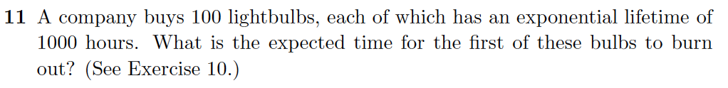

μ = 1000 (mean of exponential density of individual variable )

n = 100 (number of light bulbs)

The density of minimum value among n independent random variables with an exponential density has mean $\frac{μ}{n}$,

So the mean of the minimum value (first bulb to burn out) is:

```r
μ = 1000
n = 100

print(μ/n)
```

```
## [1] 10
```

### Question 2

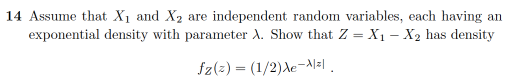

$fz(z) = (\frac{1}{2})e^{-λ|z|}$ can be rewritten as:
$$fz(z) = \begin{cases}
(\frac{1}{2})e^{-λ|z|}, z \geq 0\\
(\frac{1}{2})e^{λ|z|}, z < 0
\end{cases}$$

Since $X_1$ and $X_2$ have exponential density, their PDF is:

$$fx(x_1) = fx(x_2) = \begin{cases}
λe^{-λx}, x \geq 0\\
0, otherwise
\end{cases}$$

So the combined density is $λ^2e^{-λ(χ_1 + χ_2)}$

If $z = x_1 - x_2$ then $x_1 = z + x_2$ $=>$

If $z \geq 0$, then $x_1 = (z + x_2) \geq 0$ and

$fz(z) = \int_{z}^{∞} λ^2e^{-λ(z + 2x_2)}, dx_2 = \frac{1}{2}λe^{-λz}$

If $z < 0$, then $x_1 = (z + x_2) > 0$ and

$fz(z) = \int_{0}^{∞} λ^2e^{λ(z + 2x_2)}, dx_2 = \frac{1}{2}λe^{λz}$

then
$$fz(z) = \begin{cases}
(\frac{1}{2})e^{-λz}, z \geq 0\\
(\frac{1}{2})e^{λz}, z < 0
\end{cases}$$

### Question 3

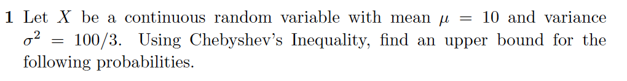

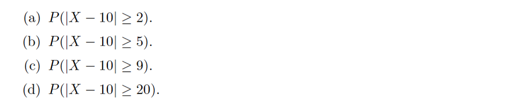

Chebyschev inequality states:

$P(| X - μ | \geq kσ ) \leq \frac{1}{k^2}$

$μ$ is given as 10, with $σ^2$ as $\frac{100}{3}$, so $σ = \frac{10}{\sqrt(3)}$

Thus,

1. $k(\frac{10}{\sqrt(3)}) = 2 \implies k = 0.3464$

so, $\frac{1}{k^2} = 8.338$

Since the upper bound cannot exceed 1, the upper bound is 1.

2. $k(\frac{10}{\sqrt(3)}) = 5 \implies k = 0.86602$

so, $\frac{1}{k^2} = 1.33334$

Since the upper bound cannot exceed 1, the upper bound is 1.

3. $k(\frac{10}{\sqrt(3)}) = 9 \implies k = 1.55884$

so, $\frac{1}{k^2} = 0.41152$

The upper bound is 0.41152.

4. $k(\frac{10}{\sqrt(3)}) = 20 \implies k = 3.4641$

so, $\frac{1}{k^2} = 0.08333$

The upper bound is 0.08333.